# Benchmarking CMEnt on True Microarray Data

CMEnt vs comb-p, probeLasso, DMRcate, and Bumphunter

CMEnt Package

2026-05-22

# Contents

## 1 Introduction

This vignette provides an extended benchmark comparing CMEnt against multiple popular DMR detection methods:

- **CMEnt**: Correlation-based seed-guided assembly approach
- **comb-p**: Combines adjacent p-values using Stouffer-Liptak-Kechris correction
- **probeLasso**: Lasso-based feature selection for DMR detection
- **DMRcate**: Gaussian kernel smoothing approach
- **Bumphunter**: Permutation-based regional testing

We evaluate these methods on:

- Number and size distribution of DMRs
- Overlap and concordance between methods
- Biological relevance of detected regions

The dataset used is CMEntdata, which contains methylation profiles for 5 cancer vs 5 normal samples.

## 2 Setup and Dependencies

```r
try(devtools::load_all(), silent = TRUE)
suppressPackageStartupMessages({
    try(library(CMEnt), silent = TRUE)
    library(minfi)
    library(data.table)
    library(ggplot2)
    library(dplyr)
    library(GenomicRanges)
})

get_benchmark_file <- function(filename) {
    benchmark_file <- ""
    folder <- "microarray"
    if (getwd() == "notebooks") {
        benchmark_file <- file.path("benchmarks", folder, filename)
    } else if ("NAMESPACE" %in% dir()) {
        benchmark_file <- file.path("notebooks", "benchmarks", folder, filename)
    } else {
        benchmark_file <- file.path("benchmarks", folder, filename)
    }
    dir.create(dirname(benchmark_file), showWarnings = FALSE, recursive = TRUE)
    benchmark_file
}
```

### 2.1 Install External Dependencies

```r
r <- getOption("repos")
if (is.null(r) || is.na(r["CRAN"]) || r["CRAN"] %in% c("@CRAN@", "")) {
  options(repos = c(CRAN = "https://cloud.r-project.org"))
}
if (!requireNamespace("BiocManager", quietly = TRUE)) {
    install.packages("BiocManager")
}

if (!requireNamespace("DMRcate", quietly = TRUE)) {
    BiocManager::install("DMRcate", update = FALSE, ask = FALSE)
}

if (!requireNamespace("bumphunter", quietly = TRUE)) {
    BiocManager::install("bumphunter", update = FALSE, ask = FALSE)
}

if (!requireNamespace("doParallel", quietly = TRUE)) {
    install.packages("doParallel")
}

if (!requireNamespace("tidyr", quietly = TRUE)) {
    install.packages("tidyr")
}

if (!requireNamespace("ChAMP", quietly = TRUE)) {
    BiocManager::install("ChAMP", update = FALSE, ask = FALSE)
}
```

**Note:** comb-p requires both the Python tool itself (combined-pvalues) and bedtools, installing using new conda env if not present:

```bash
{ command -v comb-p >/dev/null 2>&1 && command -v bedtools >/dev/null 2>&1; } || {
    echo >&2 "comb-p or bedtools not found. Installing with conda...";
    conda create -n cment_microarray_exp python=3.9
    conda activate cment_microarray_exp
    conda install -yc bioconda combined-pvalues bedtools
}
```

## 3 Load Example Data

```r
loadExampleInputData()
```

```r
genome <- "hg19"

beta_handler <- CMEnt::getBetaHandler(beta, array = array_type, genome = genome)
beta_mat <- as.matrix(beta_handler$getBeta())
locs <- beta_handler$getBetaLocs()
logit2 <- function(x) log2(x) - log2(1 - x)
mvalues <- logit2(beta_mat)
pheno$casecontrol <- pheno$Sample_Group == "cancer"
```

## 4 Find Differentially Methylated Positions

```r
dmps <- suppressWarnings(dmpFinder(mvalues,
    pheno = pheno$casecontrol,
    type = "categorical",
    shrinkVar = TRUE
))
# sort DMPs by location
dmp_locs <- locs[rownames(locs) %in% rownames(dmps), , drop = FALSE]
dmps <- dmps[rownames(dmp_locs), , drop = FALSE]
dmps <- dmps[!is.na(dmps$pval), ]
dmps$pval_adj <- p.adjust(dmps$pval, method = "BH")

case_idx <- which(pheno$casecontrol)
ctrl_idx <- which(!pheno$casecontrol)
dmps$delta_beta <- rowMeans(beta_mat[rownames(dmps), case_idx, drop = FALSE]) -
    rowMeans(beta_mat[rownames(dmps), ctrl_idx, drop = FALSE])

sig_dmps <- dmps[dmps$pval_adj < 0.01 & abs(dmps$delta_beta) >= 0.05, ]
cat(sprintf("Found %d significant DMPs (FDR < 0.01, |delta beta| >= 0.05)\n", nrow(sig_dmps)))
```

Found 138392 significant DMPs (FDR < 0.01, |delta beta| >= 0.05)

```r
dmps_gr <- makeGRangesFromDataFrame(
    data.frame(
        chr = locs$chr,
        start = locs$start,
        end = locs$end,
        pval = dmps$pval,
        qval = dmps$pval_adj,
        stat = dmps$qval
    ),
    keep.extra.columns = TRUE
)
names(dmps_gr) <- rownames(dmps)
```

## 5 Method 1: CMEnt

```r
cment_file <-  get_benchmark_file("dmrs.CMEnt.rds")
if (!file.exists(cment_file)) {
    cment_njobs <- max(1L, min(8L, future::availableCores() - 1L))
    options("CMEnt.verbose" = 1)
    options("CMEnt.njobs" = cment_njobs)
    cat(sprintf("CMEnt parallel jobs: %d\n", cment_njobs))
    cat(sprintf("future::availableCores(): %d\n", future::availableCores()))
    cat("Starting CMEnt::findDMRsFromSeeds()...\n")
    flush.console()
    start_time <- Sys.time()
    dmrs_cment <- CMEnt::findDMRsFromSeeds(
        beta = beta_handler,
        seeds = sig_dmps,
        pheno = pheno,
        sample_group_col = "Sample_Group",
        casecontrol_col = "casecontrol",
        covariates = c("Age", "Gender"),
        max_bridge_seeds_gaps  = 1,
        max_bridge_extension_gaps = 3,
        min_seeds = 2,
        min_sites = 3,
        ext_site_delta_beta = 0.2,
        max_lookup_dist = 1000,
        max_pval = 0.05,
        entanglement = "weak",
        .score_dmrs = TRUE,
        njobs = cment_njobs,
        verbose = 1
    )
    end_time <- Sys.time()
    time_cment <- end_time - start_time
    saveRDS(list(dmrs = dmrs_cment, time = time_cment), cment_file)
    rm(beta_handler)
} else {
    ret <- readRDS(cment_file)
    dmrs_cment <- ret$dmrs
    time_cment <- ret$time
}

cat(sprintf("CMEnt: Found %d DMRs in %d seconds\n", length(dmrs_cment), round(as.numeric(time_cment, units = "secs"))))
```

CMEnt: Found 12562 DMRs in 570 seconds

## 6 Method 2: comb-p

```r
combp_file <- get_benchmark_file("dmrs.combp.rds")

run_combp <- function(dmps_gr, seed = 500, dist = 500) {
    if (Sys.which("bedtools") == "") {
        warning("bedtools not found in PATH. comb-p requires bedtools to be installed.")
        warning("Install with: conda install -yc bioconda bedtools")
        return(GRanges())
    }

    if (Sys.which("comb-p") == "") {
        warning("comb-p not found in PATH.")
        warning("Install with: conda install -yc bioconda combined-pvalues")
        return(GRanges())
    }
    tmpdir <- tempdir()
    bed_file <- file.path(tmpdir, "dmps_for_combp.bed")
    bed_df <- data.frame(
        chrom = as.character(seqnames(dmps_gr)),
        start = start(dmps_gr) - 1,
        end = end(dmps_gr),
        pval = mcols(dmps_gr)$pval
    )
    bed_df <- bed_df[order(bed_df$chrom, bed_df$start), ]

    write.table(bed_df, bed_file,
        quote = FALSE, sep = "\t",
        row.names = FALSE, col.names = TRUE
    )

    cmd <- sprintf(
        "comb-p pipeline -c 4 --seed %d --dist %d -p %s --region-filter-p 0.01 --region-filter-n 3 %s",
        seed, dist, file.path(tmpdir, "output."), bed_file
    )

    tryCatch(
        {
            exit_code <- system(cmd, ignore.stdout = FALSE, ignore.stderr = FALSE)

            if (exit_code != 0) {
                warning(sprintf("comb-p exited with code %d", exit_code))
                return(GRanges())
            }

            regions_file <- paste0(file.path(tmpdir, "output."), "regions-p.bed.gz")
            if (file.exists(regions_file)) {
                regions <- fread(cmd = sprintf("zcat %s", regions_file))
                colnames(regions) <- c("chr", "start", "end", "min_p", "n_probes", "z_p", "z_sidak_p")

                regions <- regions[regions$z_sidak_p < 0.05 & regions$n_probes >= 3, ]

                dmrs_combp <- makeGRangesFromDataFrame(regions,
                    seqnames.field = "chr",
                    start.field = "start",
                    end.field = "end",
                    keep.extra.columns = TRUE
                )
                return(dmrs_combp)
            } else {
                warning("comb-p did not produce output file")
                return(GRanges())
            }
        },
        error = function(e) {
            warning(sprintf("comb-p failed: %s", e$message))
            GRanges()
        }
    )
}

if (!file.exists(combp_file)) {
    start_time <- Sys.time()
    dmrs_combp <- run_combp(dmps_gr)
    end_time <- Sys.time()
    time_combp <- end_time - start_time
    saveRDS(list(dmrs = dmrs_combp, time = time_combp), combp_file)
} else {
    ret <- readRDS(combp_file)
    dmrs_combp <- ret$dmrs
    time_combp <- ret$time
}

cat(sprintf("comb-p: Found %d DMRs in %d seconds\n", length(dmrs_combp), round(as.numeric(time_combp, units = "secs"))))
```

comb-p: Found 17981 DMRs in 70 seconds

## 7 Method 3: probeLasso

```r
probelasso_file <- get_benchmark_file("dmrs.probeLasso.rds")

run_probelasso_champ <- function(beta_mat, pheno, array_type = "450K") {
    if (!requireNamespace("ChAMP", quietly = TRUE)) {
        warning("ChAMP not installed. probeLasso requires ChAMP.")
        warning("Install with: BiocManager::install('ChAMP')")
        return(GRanges())
    }

    library(ChAMP)

    tryCatch(
        {
            result <- champ.DMR(
                beta = beta_mat,
                pheno = pheno$Sample_Group,
                arraytype = array_type,
                method = "ProbeLasso",
                minProbes = 3,
                adjPvalDmr = 0.05,
                adjPvalProbe = 0.1,
                meanLassoRadius = 500,
                minDmrSep = 500,
                minDmrSize = 50,
                PDFplot = FALSE,
                Rplot = FALSE,
                resultsDir = file.path(tempdir(), "champ_probelasso")
            )

            pl_dmr <- result$ProbeLassoDMR
            if (is.null(pl_dmr) || nrow(pl_dmr) == 0) {
                return(GRanges())
            }

            # ChAMP output column names can differ by version.
            if (!"seqnames" %in% names(pl_dmr) && "dmrChrom" %in% names(pl_dmr)) {
                pl_dmr$seqnames <- pl_dmr$dmrChrom
            }
            if (!"start" %in% names(pl_dmr) && "dmrStart" %in% names(pl_dmr)) {
                pl_dmr$start <- pl_dmr$dmrStart
            }
            if (!"end" %in% names(pl_dmr) && "dmrEnd" %in% names(pl_dmr)) {
                pl_dmr$end <- pl_dmr$dmrEnd
            }

            return(makeGRangesFromDataFrame(pl_dmr,
                seqnames.field = "seqnames",
                start.field = "start",
                end.field = "end",
                keep.extra.columns = TRUE
            ))
        },
        error = function(e) {
            warning(sprintf("probeLasso (ChAMP) failed: %s", e$message))
            GRanges()
        }
    )
}

if (!file.exists(probelasso_file)) {
    start_time <- Sys.time()
    dmrs_probelasso <- run_probelasso_champ(beta_mat, pheno, array_type = "450K")
    end_time <- Sys.time()
    time_probelasso <- end_time - start_time
    saveRDS(list(dmrs = dmrs_probelasso, time = time_probelasso), probelasso_file)
} else {
    ret <- readRDS(probelasso_file)
    dmrs_probelasso <- ret$dmrs
    time_probelasso <- ret$time
}

cat(sprintf("probeLasso: Found %d DMRs in %d seconds\n", length(dmrs_probelasso), round(as.numeric(time_probelasso, units = "secs"))))
```

probeLasso: Found 10541 DMRs in 47 seconds

## 8 Method 4: DMRcate

```r
dmrcate_file <- get_benchmark_file("dmrs.dmrcate.rds")
if (!file.exists(dmrcate_file)) {
    library(DMRcate)
    start_time <- Sys.time()
    design <- model.matrix(~Sample_Group, data = pheno)

    dmrs_dmrcate <- tryCatch(
        {
            if (ncol(design) < 2L) {
                warning("DMRcate requires at least two groups in Sample_Group; returning empty set.")
                GenomicRanges::GRanges()
            } else {
                coef_col <- ncol(design)
                colnames(design)[1] <- "(Intercept)"
                if (coef_col == 2L) {
                    colnames(design)[2] <- "cancer_vs_normal"
                }

                myannotation <- cpg.annotate("array", mvalues,
                    what = "M", arraytype = "450K",
                    analysis.type = "differential", design = design,
                    coef = coef_col, fdr = 0.05
                )

                dmrcate_results <- dmrcate(myannotation, C = 2, lambda = 1000, min.cpgs = 3, betacutoff = 0.05)
                extractRanges(dmrcate_results, genome = "hg19")
            }
        },
        error = function(e) {
            warning(sprintf("DMRcate failed: %s. Returning empty set.", e$message))
            GenomicRanges::GRanges()
        }
    )

    end_time <- Sys.time()
    time_dmrcate <- end_time - start_time
    saveRDS(list(dmrs = dmrs_dmrcate, time = time_dmrcate), dmrcate_file)
} else {
    ret <- readRDS(dmrcate_file)
    dmrs_dmrcate <- ret$dmrs
    time_dmrcate <- ret$time
}

cat(sprintf("DMRcate: Found %d DMRs in %d seconds\n", length(dmrs_dmrcate), round(as.numeric(time_dmrcate, units = "secs"))))
```

DMRcate: Found 11239 DMRs in 30 seconds

## 9 Method 5: Bumphunter

```r
bumphunter_file <- get_benchmark_file("dmrs.bumphunter.rds")
if (!file.exists(bumphunter_file)) {
    suppressPackageStartupMessages({
        library(bumphunter)
        library(doParallel)
    })
    start_time <- Sys.time()
    bh_cores <- max(1L, min(4L, future::availableCores() - 1L))
    bh_b <- 100L
    bh_max_dmrs <- 1000000L
    bh_max_gap <- 2000L
    bh_min_l <- 2L
    bh_region_p <- 0.05

    doParallel::registerDoParallel(cores = bh_cores)
    on.exit({
        try(doParallel::stopImplicitCluster(), silent = TRUE)
        gc()
    }, add = TRUE)

    design <- model.matrix(~Sample_Group, data = pheno)
    bh_cluster <- bumphunter::clusterMaker(
        chr = as.character(locs$chr),
        pos = locs$start,
        maxGap = bh_max_gap
    )
    run_bumphunter_fit <- function(cutoff, B) {
        bumphunter(beta_mat,
            design = design,
            chr = as.character(locs$chr),
            pos = locs$start,
            cluster = bh_cluster,
            cutoff = cutoff,
            maxGap = max_gap,
            nullMethod = "bootstrap",
            B = B,
            type = "Beta",
            coef = 2
        )
    }
    has_informative_bumphunter_null <- function(fit) {
        null_values <- unlist(fit$null$value, use.names = FALSE)
        null_lengths <- unlist(fit$null$length, use.names = FALSE)
        length(null_values) > 0 &&
            any(abs(null_values) > 0) &&
            length(null_lengths) > 0 &&
            any(null_lengths > 0)
    }
    max_gap <- bh_max_gap
    dmrs_cutoff <- 0.1
    dmrs_cnt <- Inf
    iter <- 0L
    max_iter <- 10L
    while (dmrs_cnt > bh_max_dmrs && iter < max_iter) {
        iter <- iter + 1L
        dmrs <- run_bumphunter_fit(cutoff = dmrs_cutoff, B = 0)
        dmrs_cnt <- nrow(dmrs$table)
        dmrs_cutoff <- dmrs_cutoff * 1.2
        rm(dmrs)
        gc()
    }
    final_cutoff <- dmrs_cutoff / 1.2
    cat(sprintf(
        "Bumphunter: cutoff=%.4f, candidate_bumps=%d, minL=%d, maxGap=%d, cores=%d, B=%d\n",
        final_cutoff, dmrs_cnt, bh_min_l, max_gap, bh_cores, bh_b
    ))
    bumphunter_results <- run_bumphunter_fit(cutoff = final_cutoff, B = bh_b)
    bh_cutoff_floor <- 0.005
    bh_bootstrap_adjust_iter <- 0L
    bh_max_bootstrap_adjust <- 6L
    while (
        nrow(bumphunter_results$table) > 0 &&
            (all(is.na(bumphunter_results$table$p.value)) ||
                !has_informative_bumphunter_null(bumphunter_results)) &&
            final_cutoff > bh_cutoff_floor &&
            bh_bootstrap_adjust_iter < bh_max_bootstrap_adjust
    ) {
        prev_cutoff <- final_cutoff
        final_cutoff <- max(final_cutoff / 2, bh_cutoff_floor)
        if (identical(final_cutoff, prev_cutoff)) {
            break
        }
        bh_bootstrap_adjust_iter <- bh_bootstrap_adjust_iter + 1L
        cat(sprintf(
            "Bumphunter: bootstrap null degenerate at cutoff=%.4f; retrying with cutoff=%.4f\n",
            prev_cutoff, final_cutoff
        ))
        bumphunter_results <- run_bumphunter_fit(cutoff = final_cutoff, B = bh_b)
    }

    dmr_table <- bumphunter_results$table
    # bumphunter already estimates region-level p-values from the bootstrap null.
    dmr_table <- dmr_table[dmr_table$L >= bh_min_l & dmr_table$p.value <= bh_region_p, ]

    dmrs_bumphunter <- makeGRangesFromDataFrame(dmr_table,
        seqnames.field = "chr",
        start.field = "start",
        end.field = "end",
        keep.extra.columns = TRUE
    )
    end_time <- Sys.time()
    time_bumphunter <- end_time - start_time
    saveRDS(list(dmrs = dmrs_bumphunter, time = time_bumphunter), bumphunter_file)
} else {
    ret <- readRDS(bumphunter_file)
    dmrs_bumphunter <- ret$dmrs
    time_bumphunter <- ret$time
}

cat(sprintf("Bumphunter: Found %d DMRs in %d seconds\n", length(dmrs_bumphunter), round(as.numeric(time_bumphunter, units = "secs"))))
```

Bumphunter: Found 11372 DMRs in 310 seconds

## 10 Comparative Analysis

### 10.1 Basic Statistics

```r
get_dmr_stats <- function(dmrs, method) {
    if (length(dmrs) == 0) {
        return(data.frame(
            Method = method,
            `Number of DMRs` = 0,
            `Mean DMR Width` = NA,
            `Median DMR Width` = NA,
            `Total Coverage bp` = 0,
            `Min Width` = NA,
            `Max Width` = NA
        ))
    }

    data.frame(
        Method = method,
        `Number of DMRs` = length(dmrs),
        `Mean DMR Width` = round(mean(width(dmrs)), 1),
        `Median DMR Width` = median(width(dmrs)),
        `Total Coverage bp` = sum(width(dmrs)),
        `Min Width` = min(width(dmrs)),
        `Max Width` = max(width(dmrs))
    )
}

stats_list <- list(
    get_dmr_stats(dmrs_cment, "CMEnt"),
    get_dmr_stats(dmrs_combp, "comb-p"),
    get_dmr_stats(dmrs_probelasso, "probeLasso"),
    get_dmr_stats(dmrs_dmrcate, "DMRcate"),
    get_dmr_stats(dmrs_bumphunter, "Bumphunter")
)

results_comparison <- do.call(rbind, stats_list)
knitr::kable(results_comparison, digits = 2, caption = "Basic DMR Statistics Across Methods")
```

Table 1: Basic DMR Statistics Across Methods

| Method | Number.of.DMRs | Mean.DMR.Width | Median.DMR.Width | Total.Coverage.bp | Min.Width | Max.Width |
| --- | --- | --- | --- | --- | --- | --- |
| CMEnt | 12562 | 961.7 | 754 | 12080749 | 7 | 10546 |
| comb-p | 17981 | 930.2 | 816 | 16725476 | 9 | 10159 |
| probeLasso | 10541 | 2426.2 | 2033 | 25574771 | 52 | 26740 |
| DMRcate | 11239 | 1103.0 | 896 | 12396187 | 10 | 13647 |
| Bumphunter | 11372 | 498.4 | 260 | 5667409 | 3 | 11785 |

### 10.2 Pairwise Overlap Analysis

```r
methods_list <- list(
    CMEnt = dmrs_cment,
    `comb-p` = dmrs_combp,
    probeLasso = dmrs_probelasso,
    DMRcate = dmrs_dmrcate,
    Bumphunter = dmrs_bumphunter
)

methods_list <- methods_list[sapply(methods_list, length) > 0]

calculate_overlap <- function(gr1, gr2) {
    if (length(gr1) == 0 || length(gr2) == 0) {
        return(list(count = 0, percentage = 0))
    }
    overlap_count <- length(subsetByOverlaps(gr1, gr2))
    pct <- (overlap_count / length(gr1)) * 100
    list(count = overlap_count, percentage = pct)
}

overlap_matrix <- matrix(0, nrow = length(methods_list), ncol = length(methods_list))
pct_matrix <- matrix(0, nrow = length(methods_list), ncol = length(methods_list))
rownames(overlap_matrix) <- colnames(overlap_matrix) <- names(methods_list)
rownames(pct_matrix) <- colnames(pct_matrix) <- names(methods_list)

for (i in seq_along(methods_list)) {
    for (j in seq_along(methods_list)) {
        if (i == j) {
            overlap_matrix[i, j] <- length(methods_list[[i]])
            pct_matrix[i, j] <- 100
        } else {
            overlap_result <- calculate_overlap(methods_list[[i]], methods_list[[j]])
            overlap_matrix[i, j] <- overlap_result$count
            pct_matrix[i, j] <- overlap_result$percentage
        }
    }
}

cat("\n#### Overlap Counts (rows overlap with columns)\n")
```

#### 10.2.1 Overlap Counts (rows overlap with columns)

```r
knitr::kable(overlap_matrix, digits = 0, caption = "Number of DMRs from Method A (rows) overlapping with Method B (columns)")
```

Table 2: Number of DMRs from Method A (rows) overlapping with Method B (columns)

|  | CMEnt | comb-p | probeLasso | DMRcate | Bumphunter |
| --- | --- | --- | --- | --- | --- |
| CMEnt | 12562 | 10138 | 5800 | 7043 | 6116 |
| comb-p | 10086 | 17981 | 7772 | 9326 | 6773 |
| probeLasso | 5476 | 7537 | 10541 | 5279 | 3902 |
| DMRcate | 6668 | 8630 | 5305 | 11239 | 6359 |
| Bumphunter | 7110 | 7552 | 4397 | 7416 | 11372 |

```r
cat("\n#### Overlap Percentages\n")
```

#### 10.2.2 Overlap Percentages

```r
knitr::kable(pct_matrix, digits = 2, caption = "Percentage of DMRs from Method A (rows) overlapping with Method B (columns)")
```

Table 2: Percentage of DMRs from Method A (rows) overlapping with Method B (columns)

|  | CMEnt | comb-p | probeLasso | DMRcate | Bumphunter |
| --- | --- | --- | --- | --- | --- |
| CMEnt | 100.00 | 80.70 | 46.17 | 56.07 | 48.69 |
| comb-p | 56.09 | 100.00 | 43.22 | 51.87 | 37.67 |
| probeLasso | 51.95 | 71.50 | 100.00 | 50.08 | 37.02 |
| DMRcate | 59.33 | 76.79 | 47.20 | 100.00 | 56.58 |
| Bumphunter | 62.52 | 66.41 | 38.67 | 65.21 | 100.00 |

### 10.3 Jaccard Index and IoU

```r
jaccard_index <- function(gr1, gr2) {
    if (length(gr1) == 0 || length(gr2) == 0) {
        return(0)
    }
    overlap_count <- length(subsetByOverlaps(gr1, gr2))
    total_unique <- length(unique(c(gr1, gr2)))
    if (total_unique == 0) {
        return(0)
    }
    overlap_count / total_unique
}

iou <- function(gr1, gr2) {
    if (length(gr1) == 0 || length(gr2) == 0) {
        return(0)
    }
    intersection <- sum(width(GenomicRanges::intersect(gr1, gr2)))
    union <- sum(width(GenomicRanges::union(gr1, gr2)))
    if (union == 0) {
        return(0)
    }
    intersection / union
}

jaccard_matrix <- matrix(0, nrow = length(methods_list), ncol = length(methods_list))
iou_matrix <- matrix(0, nrow = length(methods_list), ncol = length(methods_list))
rownames(jaccard_matrix) <- colnames(jaccard_matrix) <- names(methods_list)
rownames(iou_matrix) <- colnames(iou_matrix) <- names(methods_list)

for (i in seq_along(methods_list)) {
    for (j in seq_along(methods_list)) {
        if (i < j) {
            jaccard_matrix[i, j] <- jaccard_matrix[j, i] <- jaccard_index(methods_list[[i]], methods_list[[j]])
            iou_matrix[i, j] <- iou_matrix[j, i] <- iou(methods_list[[i]], methods_list[[j]])
        } else if (i == j) {
            jaccard_matrix[i, j] <- 1
            iou_matrix[i, j] <- 1
        }
    }
}

cat("\n#### Jaccard Index\n")
```

#### 10.3.1 Jaccard Index

```r
knitr::kable(jaccard_matrix, digits = 4, caption = "Jaccard Index (region count-based similarity)")
```

Table 3: Jaccard Index (region count-based similarity)

|  | CMEnt | comb-p | probeLasso | DMRcate | Bumphunter |
| --- | --- | --- | --- | --- | --- |
| CMEnt | 1.0000 | 0.3319 | 0.2510 | 0.3274 | 0.2628 |
| comb-p | 0.3319 | 1.0000 | 0.2725 | 0.3192 | 0.2307 |
| probeLasso | 0.2510 | 0.2725 | 1.0000 | 0.2424 | 0.1781 |
| DMRcate | 0.3274 | 0.3192 | 0.2424 | 1.0000 | 0.2903 |
| Bumphunter | 0.2628 | 0.2307 | 0.1781 | 0.2903 | 1.0000 |

```r
cat("\n#### Intersection over Union (IoU)\n")
```

#### 10.3.2 Intersection over Union (IoU)

```r
knitr::kable(iou_matrix, digits = 4, caption = "IoU (genomic coverage-based similarity)")
```

Table 3: IoU (genomic coverage-based similarity)

|  | CMEnt | comb-p | probeLasso | DMRcate | Bumphunter |
| --- | --- | --- | --- | --- | --- |
| CMEnt | 1.0000 | 0.3137 | 0.0839 | 0.3332 | 0.1576 |
| comb-p | 0.3137 | 1.0000 | 0.0920 | 0.3336 | 0.1049 |
| probeLasso | 0.0839 | 0.0920 | 1.0000 | 0.0941 | 0.0497 |
| DMRcate | 0.3332 | 0.3336 | 0.0941 | 1.0000 | 0.1898 |
| Bumphunter | 0.1576 | 0.1049 | 0.0497 | 0.1898 | 1.0000 |

## 11 Visualizations

### 11.1 DMR Count and Coverage Comparison

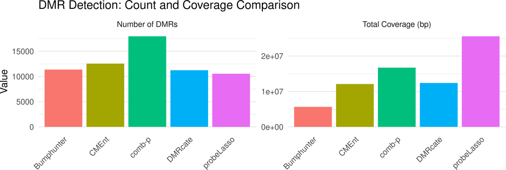

```r
viz_data <- results_comparison |>
    dplyr::select(Method, Number.of.DMRs, Total.Coverage.bp) |>
    tidyr::pivot_longer(
        cols = c(Number.of.DMRs, Total.Coverage.bp),
        names_to = "Metric", values_to = "Value"
    )

viz_data$Metric <- ifelse(viz_data$Metric == "Number.of.DMRs",
    "Number of DMRs",
    "Total Coverage (bp)"
)

p1 <- ggplot(viz_data, aes(x = Method, y = Value, fill = Method)) +
    geom_bar(stat = "identity") +
    facet_wrap(~Metric, scales = "free_y") +
    theme_minimal() +
    theme(
        axis.text.x = element_text(angle = 45, hjust = 1),
        legend.position = "none",
        panel.grid.major.x = element_blank()
    ) +
    labs(
        title = "DMR Detection: Count and Coverage Comparison",
        y = "Value", x = ""
    )

print(p1)
```

### 11.2 DMR Width Distribution

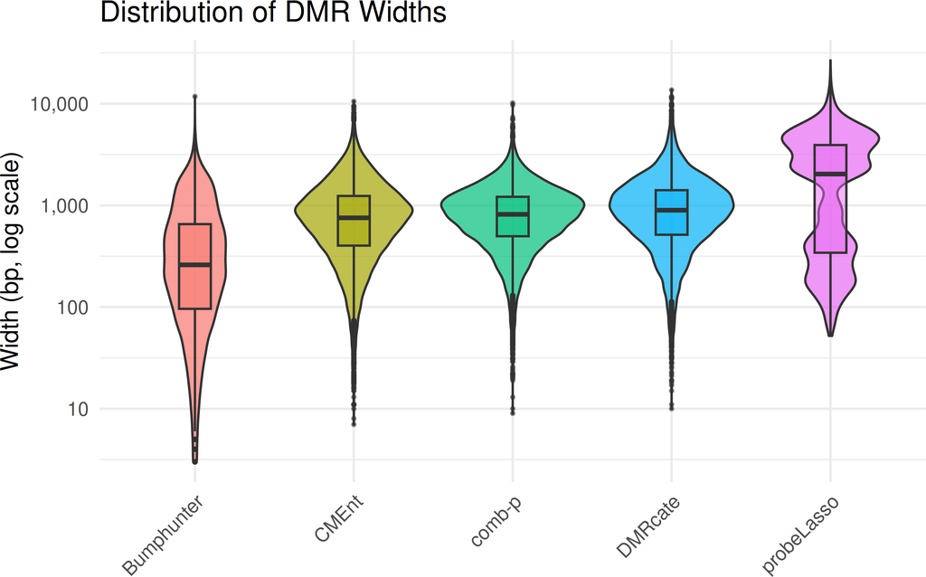

```r
width_data <- do.call(rbind, lapply(names(methods_list), function(method) {
    if (length(methods_list[[method]]) > 0) {
        data.frame(
            Method = method,
            Width = width(methods_list[[method]])
        )
    }
}))

p2 <- ggplot(width_data, aes(x = Method, y = Width, fill = Method)) +
    geom_violin(alpha = 0.7) +
    geom_boxplot(width = 0.2, alpha = 0.5, outlier.size = 0.5) +
    scale_y_log10(labels = scales::comma) +
    theme_minimal() +
    theme(
        axis.text.x = element_text(angle = 45, hjust = 1),
        legend.position = "none"
    ) +
    labs(
        title = "Distribution of DMR Widths",
        y = "Width (bp, log scale)", x = ""
    )

print(p2)
```

### 11.3 Overlap Heatmap

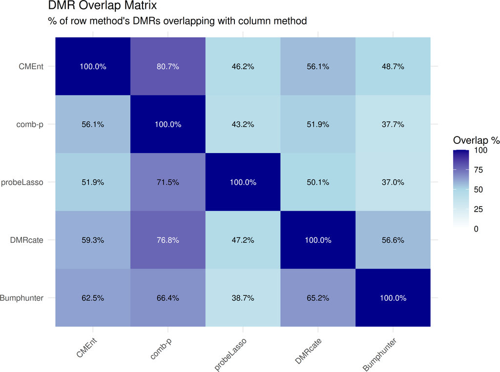

```r
library(reshape2)

heatmap_text_color <- function(value, low, mid, high, midpoint, limits) {
    value <- pmin(pmax(value, limits[1]), limits[2])

    interpolate_color <- function(x) {
        if (!is.finite(x)) {
            return("#FFFFFF")
        }

        if (x <= midpoint) {
            ratio <- if (midpoint == limits[1]) 1 else (x - limits[1]) / (midpoint - limits[1])
            anchors <- grDevices::col2rgb(c(low, mid)) / 255
        } else {
            ratio <- if (midpoint == limits[2]) 1 else (x - midpoint) / (limits[2] - midpoint)
            anchors <- grDevices::col2rgb(c(mid, high)) / 255
        }

        rgb <- anchors[, 1] + pmin(pmax(ratio, 0), 1) * (anchors[, 2] - anchors[, 1])
        grDevices::rgb(rgb[1], rgb[2], rgb[3])
    }

    fill_colors <- vapply(value, interpolate_color, character(1))
    rgb <- t(grDevices::col2rgb(fill_colors) / 255)
    rgb_linear <- ifelse(rgb <= 0.04045, rgb / 12.92, ((rgb + 0.055) / 1.055)^2.4)
    luminance <- rgb_linear[, 1] * 0.2126 + rgb_linear[, 2] * 0.7152 + rgb_linear[, 3] * 0.0722
    black_contrast <- (luminance + 0.05) / 0.05
    white_contrast <- 1.05 / (luminance + 0.05)
    ifelse(white_contrast > black_contrast, "white", "black")
}

heatmap_levels <- names(methods_list)

overlap_df <- melt(pct_matrix)
colnames(overlap_df) <- c("Method1", "Method2", "Percentage")
overlap_df$Method1 <- factor(overlap_df$Method1, levels = rev(heatmap_levels))
overlap_df$Method2 <- factor(overlap_df$Method2, levels = heatmap_levels)
overlap_df$LabelColor <- heatmap_text_color(
    overlap_df$Percentage,
    low = "white", mid = "lightblue", high = "darkblue",
    midpoint = 50, limits = c(0, 100)
)

p3 <- ggplot(overlap_df, aes(x = Method2, y = Method1, fill = Percentage)) +
    geom_tile() +
    geom_text(aes(label = sprintf("%.1f%%", Percentage), color = LabelColor), size = 3) +
    scale_fill_gradient2(
        low = "white", mid = "lightblue", high = "darkblue",
        midpoint = 50, limits = c(0, 100)
    ) +
    scale_color_identity() +
    theme_minimal() +
    theme(axis.text.x = element_text(angle = 45, hjust = 1)) +
    labs(
        title = "DMR Overlap Matrix",
        subtitle = "% of row method's DMRs overlapping with column method",
        x = "", y = "", fill = "Overlap %"
    )

print(p3)
```

### 11.4 Similarity Matrix (IoU)

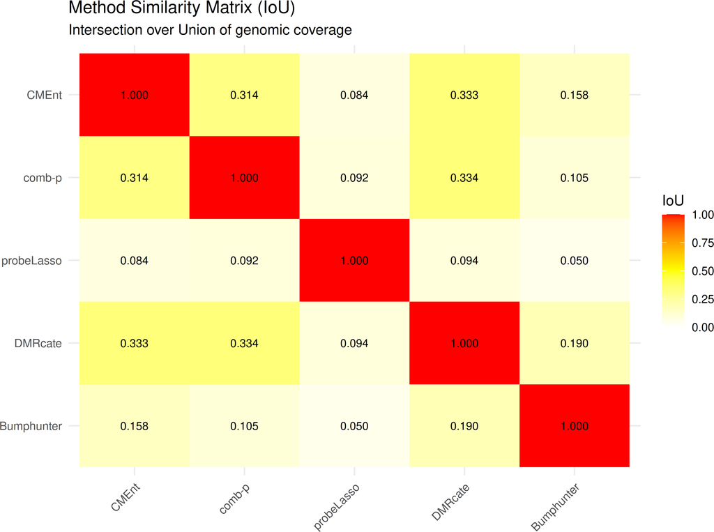

```r
iou_df <- melt(iou_matrix)
colnames(iou_df) <- c("Method1", "Method2", "IoU")
iou_df$Method1 <- factor(iou_df$Method1, levels = rev(heatmap_levels))
iou_df$Method2 <- factor(iou_df$Method2, levels = heatmap_levels)
iou_df$LabelColor <- heatmap_text_color(
    iou_df$IoU,
    low = "white", mid = "yellow", high = "red",
    midpoint = 0.5, limits = c(0, 1)
)

p4 <- ggplot(iou_df, aes(x = Method2, y = Method1, fill = IoU)) +
    geom_tile() +
    geom_text(aes(label = sprintf("%.3f", IoU), color = LabelColor), size = 3) +
    scale_fill_gradient2(
        low = "white", mid = "yellow", high = "red",
        midpoint = 0.5, limits = c(0, 1)
    ) +
    scale_color_identity() +
    theme_minimal() +
    theme(axis.text.x = element_text(angle = 45, hjust = 1)) +
    labs(
        title = "Method Similarity Matrix (IoU)",
        subtitle = "Intersection over Union of genomic coverage",
        x = "", y = "", fill = "IoU"
    )

print(p4)
```

## 12 Biological Validation

### 12.1 Effect Size Analysis (Delta Beta)

```r
calculate_mean_delta_beta <- function(dmrs, beta_mat, pheno, locs, group_col = "Sample_Group", max_dmrs = 5000) {
    if (length(dmrs) == 0) {
        return(NA)
    }

    if (length(dmrs) > max_dmrs) {
        set.seed(42)
        dmrs <- dmrs[sample(length(dmrs), max_dmrs)]
    }

    case_samples <- colnames(beta_mat)[pheno[[group_col]] == "cancer"]
    control_samples <- colnames(beta_mat)[pheno[[group_col]] == "normal"]

    site_gr <- makeGRangesFromDataFrame(locs)
    names(site_gr) <- rownames(beta_mat)

    hits <- findOverlaps(site_gr, dmrs)
    if (length(hits) == 0) {
        return(NA)
    }

    site_idx <- queryHits(hits)
    dmr_idx <- subjectHits(hits)

    case_means <- rowMeans(beta_mat[site_idx, case_samples, drop = FALSE], na.rm = TRUE)
    control_means <- rowMeans(beta_mat[site_idx, control_samples, drop = FALSE], na.rm = TRUE)
    delta_per_site <- abs(case_means - control_means)

    dmr_deltas <- tapply(delta_per_site, dmr_idx, mean, na.rm = TRUE)
    mean(dmr_deltas, na.rm = TRUE)
}

effect_size_list <- lapply(names(methods_list), function(method) {
    data.frame(
        Method = method,
        Mean_Delta_Beta = calculate_mean_delta_beta(methods_list[[method]], beta_mat, pheno, locs)
    )
})

effect_size_df <- do.call(rbind, effect_size_list)
knitr::kable(effect_size_df, digits = 4, caption = "Mean Effect Size (Delta Beta) per Method")
```

Table 4: Mean Effect Size (Delta Beta) per Method

| Method | Mean_Delta_Beta |
| --- | --- |
| CMEnt | 0.1013 |
| comb-p | 0.0903 |
| probeLasso | 0.0942 |
| DMRcate | 0.1111 |
| Bumphunter | 0.1823 |

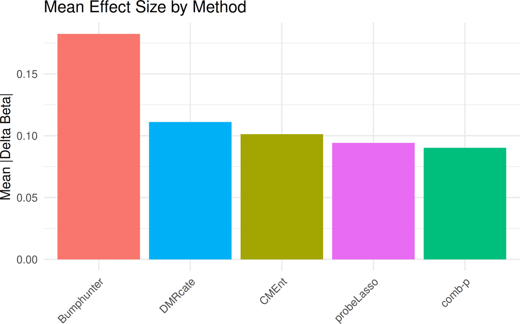

```r
ggplot(effect_size_df, aes(x = reorder(Method, -Mean_Delta_Beta), y = Mean_Delta_Beta, fill = Method)) +
    geom_bar(stat = "identity") +
    theme_minimal() +
    theme(axis.text.x = element_text(angle = 45, hjust = 1), legend.position = "none") +
    labs(title = "Mean Effect Size by Method", x = "", y = "Mean |Delta Beta|")
```

### 12.2 Gene Annotation Analysis

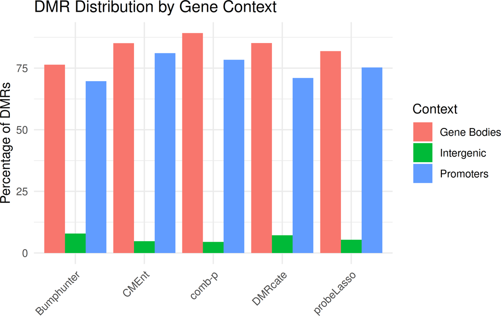

```r
if (requireNamespace("TxDb.Hsapiens.UCSC.hg19.knownGene", quietly = TRUE)) {
    library(TxDb.Hsapiens.UCSC.hg19.knownGene)
    txdb <- TxDb.Hsapiens.UCSC.hg19.knownGene

    promoters_gr <- promoters(txdb, upstream = 2000, downstream = 500)
    genes_gr <- genes(txdb)

    annotate_dmrs <- function(dmrs, method_name) {
        if (length(dmrs) == 0) {
            return(data.frame(
                Method = method_name,
                Total_DMRs = 0,
                In_Promoters = 0,
                In_Gene_Bodies = 0,
                Intergenic = 0,
                Pct_Promoters = 0,
                Pct_Gene_Bodies = 0,
                Pct_Intergenic = 0
            ))
        }

        in_promoters <- sum(overlapsAny(dmrs, promoters_gr))
        in_genes <- sum(overlapsAny(dmrs, genes_gr))
        intergenic <- length(dmrs) - sum(overlapsAny(dmrs, c(promoters_gr, genes_gr)))

        data.frame(
            Method = method_name,
            Total_DMRs = length(dmrs),
            In_Promoters = in_promoters,
            In_Gene_Bodies = in_genes,
            Intergenic = intergenic,
            Pct_Promoters = round(100 * in_promoters / length(dmrs), 1),
            Pct_Gene_Bodies = round(100 * in_genes / length(dmrs), 1),
            Pct_Intergenic = round(100 * intergenic / length(dmrs), 1)
        )
    }

    gene_annotation_list <- lapply(names(methods_list), function(method) {
        annotate_dmrs(methods_list[[method]], method)
    })

    gene_annotation_df <- do.call(rbind, gene_annotation_list)
    knitr::kable(gene_annotation_df, caption = "DMR Gene Context Annotation")

    gene_plot_data <- gene_annotation_df |>
        dplyr::select(Method, Pct_Promoters, Pct_Gene_Bodies, Pct_Intergenic) |>
        tidyr::pivot_longer(cols = -Method, names_to = "Context", values_to = "Percentage")

    gene_plot_data$Context <- gsub("Pct_", "", gene_plot_data$Context)
    gene_plot_data$Context <- gsub("_", " ", gene_plot_data$Context)

    ggplot(gene_plot_data, aes(x = Method, y = Percentage, fill = Context)) +
        geom_bar(stat = "identity", position = "dodge") +
        theme_minimal() +
        theme(axis.text.x = element_text(angle = 45, hjust = 1)) +
        labs(title = "DMR Distribution by Gene Context", x = "", y = "Percentage of DMRs")
}
```

### 12.3 site Context Distribution

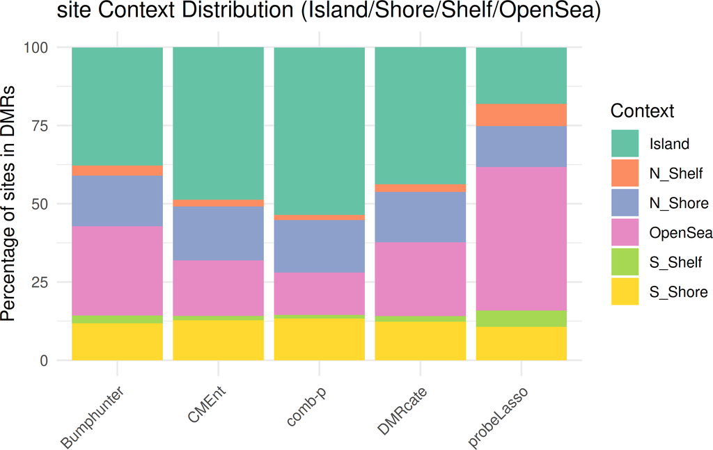

```r
if (requireNamespace("IlluminaHumanMethylation450kanno.ilmn12.hg19", quietly = TRUE)) {
    library(IlluminaHumanMethylation450kanno.ilmn12.hg19)
    anno <- getAnnotation(IlluminaHumanMethylation450kanno.ilmn12.hg19)

    site_context_gr <- makeGRangesFromDataFrame(
        data.frame(
            chr = anno$chr,
            start = anno$pos,
            end = anno$pos,
            context = anno$Relation_to_Island
        ),
        keep.extra.columns = TRUE
    )
    names(site_context_gr) <- rownames(anno)

    get_site_context_distribution <- function(dmrs, method_name) {
        if (length(dmrs) == 0) {
            return(data.frame(Method = method_name, Context = NA, Count = 0, Percentage = 0))
        }

        overlapping <- subsetByOverlaps(site_context_gr, dmrs)
        context_counts <- table(mcols(overlapping)$context)

        data.frame(
            Method = method_name,
            Context = names(context_counts),
            Count = as.vector(context_counts),
            Percentage = round(100 * as.vector(context_counts) / sum(context_counts), 1)
        )
    }

    site_context_list <- lapply(names(methods_list), function(method) {
        get_site_context_distribution(methods_list[[method]], method)
    })

    site_context_df <- do.call(rbind, site_context_list)
    site_context_df <- site_context_df[!is.na(site_context_df$Context), ]

    ggplot(site_context_df, aes(x = Method, y = Percentage, fill = Context)) +
        geom_bar(stat = "identity", position = "stack") +
        theme_minimal() +
        theme(axis.text.x = element_text(angle = 45, hjust = 1)) +
        scale_fill_brewer(palette = "Set2") +
        labs(
            title = "site Context Distribution (Island/Shore/Shelf/OpenSea)",
            x = "", y = "Percentage of sites in DMRs"
        )
}
```

## 13 Consensus Analysis

### 13.1 UpSet Plot of Method Intersections

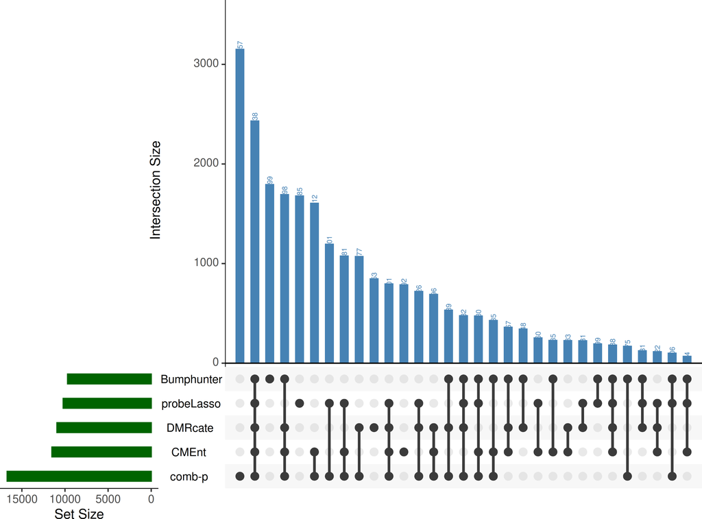

```r
if (requireNamespace("UpSetR", quietly = TRUE) && length(methods_list) >= 2) {
    library(UpSetR)

    all_dmrs_reduced <- GenomicRanges::reduce(do.call(c, unname(methods_list)))

    membership_matrix <- sapply(methods_list, function(method_dmrs) {
        as.integer(overlapsAny(all_dmrs_reduced, method_dmrs))
    })

    membership_df <- as.data.frame(membership_matrix)
    colnames(membership_df) <- names(methods_list)

    upset_plot <- upset(membership_df,
        sets = names(methods_list),
        order.by = "freq",
        main.bar.color = "steelblue",
        sets.bar.color = "darkgreen",
        text.scale = c(1.3, 1.3, 1.3, 1.3, 1.3, 0.9),
        point.size = 3,
        line.size = 1,
        show.numbers = "yes",
        number.angles = 90
    )

    # Recenter rotated number labels over bars (UpSetR fixes vjust = -1 internally).
    panel_idx <- which(upset_plot$Main_bar$layout$name == "panel")
    if (length(panel_idx) == 1) {
        panel_grob <- upset_plot$Main_bar$grobs[[panel_idx]]
        text_children <- names(panel_grob$children)[vapply(panel_grob$children, inherits, logical(1), what = "text")]
        if (length(text_children) >= 1) {
            text_grob <- panel_grob$children[[text_children[1]]]
            text_grob$hjust <- 0.5
            text_grob$vjust <- 0.5
            panel_grob$children[[text_children[1]]] <- text_grob
            upset_plot$Main_bar$grobs[[panel_idx]] <- panel_grob
        }
    }

    print(upset_plot)
}
```

### 13.2 Consensus DMR Analysis

```r
find_consensus <- function(methods_list, min_methods = 2) {
    all_dmrs <- do.call(c, unname(methods_list))
    all_dmrs <- GenomicRanges::reduce(all_dmrs)

    overlap_matrix <- sapply(methods_list, function(method_dmrs) {
        overlapsAny(all_dmrs, method_dmrs)
    })
    consensus_counts <- rowSums(overlap_matrix)

    consensus_dmrs <- all_dmrs[consensus_counts >= min_methods]
    mcols(consensus_dmrs)$n_methods <- consensus_counts[consensus_counts >= min_methods]
    consensus_dmrs
}

consensus_2plus <- find_consensus(methods_list, min_methods = 2)
consensus_3plus <- find_consensus(methods_list, min_methods = 3)
consensus_4plus <- find_consensus(methods_list, min_methods = 4)
cat(sprintf("- Consensus DMRs (2+ methods): %d\n", length(consensus_2plus)))
```

- Consensus DMRs (2+ methods): 15935

```r
cat(sprintf("- Consensus DMRs (3+ methods): %d\n", length(consensus_3plus)))
```

- Consensus DMRs (3+ methods): 10364

```r
cat(sprintf("- Consensus DMRs (4+ methods): %d\n", length(consensus_4plus)))
```

- Consensus DMRs (4+ methods): 6087

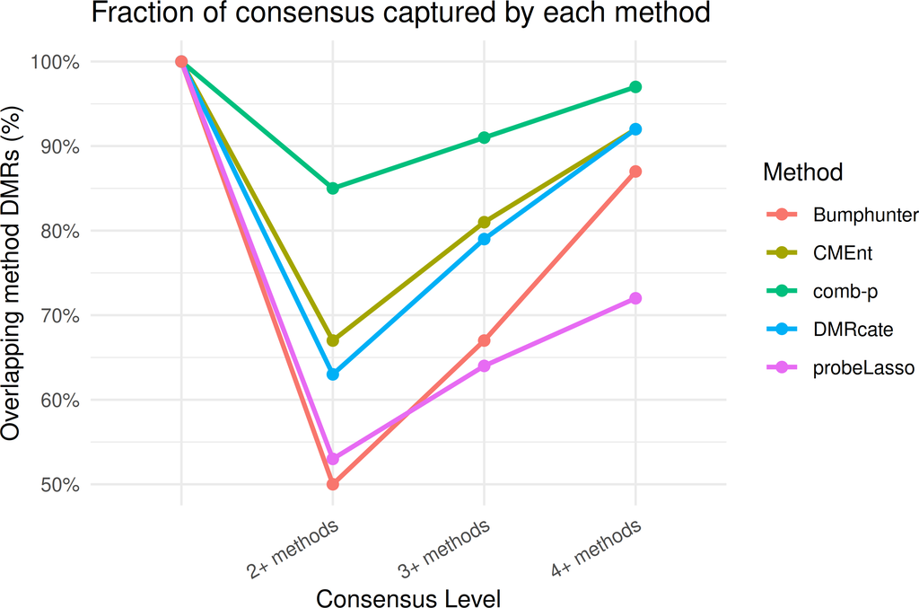

```r
consensus_sets <- list(
    `2+ methods` = consensus_2plus,
    `3+ methods` = consensus_3plus,
    `4+ methods` = consensus_4plus
)

consensus_overlap_trend <- do.call(rbind, lapply(names(methods_list), function(method) {
    method_dmrs <- methods_list[[method]]
    overlap_counts <- sapply(consensus_sets, function(consensus_dmrs) {
        if (length(method_dmrs) == 0 || length(consensus_dmrs) == 0) {
            return(0L)
        }
        round(sum(overlapsAny(consensus_dmrs, method_dmrs)) / length(consensus_dmrs), 2)
    })

    data.frame(
        Method = method,
        Consensus_Level = factor(
            c("", names(consensus_sets)),
            levels = c("", names(consensus_sets))
        ),
        Overlapping_DMRs = c(1, overlap_counts)
    )
}))

ggplot(consensus_overlap_trend, aes(
    x = Consensus_Level,
    y = Overlapping_DMRs,
    color = Method,
    group = Method
)) +
    geom_line(linewidth = 1) +
    geom_point(size = 2) +
    scale_y_continuous(labels = scales::percent_format(accuracy = 1)) +
    theme_minimal() +
    theme(axis.text.x = element_text(angle = 30, hjust = 1)) +
    labs(
        title = "Fraction of consensus captured by each method",
        x = "Consensus Level",
        y = "Overlapping method DMRs (%)",
        color = "Method"
    )
```

```r
capture_rate <- sapply(names(methods_list), function(method) {
    if (length(consensus_3plus) == 0) {
        return(0)
    }
    sum(overlapsAny(consensus_3plus, methods_list[[method]])) / length(consensus_3plus) * 100
})

capture_df <- data.frame(
    Method = names(capture_rate),
    Capture_Rate_Pct = capture_rate
)
capture_df <- capture_df[order(-capture_df$Capture_Rate_Pct), ]

knitr::kable(capture_df,
    digits = 1, row.names = FALSE,
    caption = "% of High-Confidence (3+ methods) DMRs Captured by Each Method"
)
```

Table 5: % of High-Confidence (3+ methods) DMRs Captured by Each Method

| Method | Capture_Rate_Pct |
| --- | --- |
| comb-p | 91.5 |
| CMEnt | 80.9 |
| DMRcate | 79.0 |
| Bumphunter | 66.9 |
| probeLasso | 64.0 |

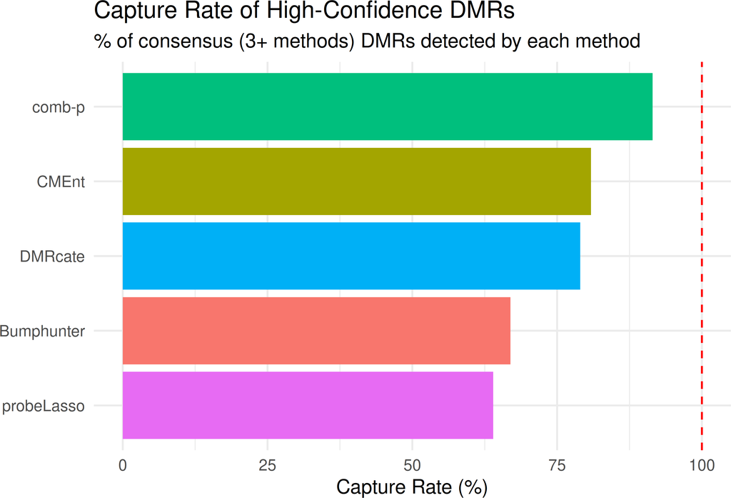

```r
ggplot(capture_df, aes(x = reorder(Method, Capture_Rate_Pct), y = Capture_Rate_Pct, fill = Method)) +
    geom_bar(stat = "identity") +
    coord_flip() +
    theme_minimal() +
    theme(legend.position = "none") +
    geom_hline(yintercept = 100, linetype = "dashed", color = "red") +
    labs(
        title = "Capture Rate of High-Confidence DMRs",
        subtitle = "% of consensus (3+ methods) DMRs detected by each method",
        x = "", y = "Capture Rate (%)"
    )
```

### 13.3 Method-Specific vs Consensus DMRs

```r
find_specific_dmrs <- function(target_method, methods_list) {
    target_dmrs <- methods_list[[target_method]]
    if (length(target_dmrs) == 0) {
        return(GRanges())
    }

    other_methods <- methods_list[names(methods_list) != target_method]
    all_others <- do.call(c, unname(other_methods))

    if (length(all_others) == 0) {
        return(target_dmrs)
    }

    specific <- target_dmrs[countOverlaps(target_dmrs, all_others) == 0]
    specific
}

specificity_df <- do.call(rbind, lapply(names(methods_list), function(method) {
    specific <- find_specific_dmrs(method, methods_list)
    shared_2plus <- methods_list[[method]][overlapsAny(methods_list[[method]], consensus_2plus)]
    shared_3plus <- methods_list[[method]][overlapsAny(methods_list[[method]], consensus_3plus)]

    data.frame(
        Method = method,
        Total_DMRs = length(methods_list[[method]]),
        Method_Specific = length(specific),
        Shared_2plus = length(shared_2plus),
        Shared_3plus = length(shared_3plus),
        Pct_Specific = round(100 * length(specific) / max(1, length(methods_list[[method]])), 1),
        Pct_Shared_2plus = round(100 * length(shared_2plus) / max(1, length(methods_list[[method]])), 1),
        Pct_Shared_3plus = round(100 * length(shared_3plus) / max(1, length(methods_list[[method]])), 1)
    )
}))

knitr::kable(specificity_df, caption = "Method-Specific vs Shared DMRs")
```

Table 6: Method-Specific vs Shared DMRs

| Method | Total_DMRs | Method_Specific | Shared_2plus | Shared_3plus | Pct_Specific | Pct_Shared_2plus | Pct_Shared_3plus |
| --- | --- | --- | --- | --- | --- | --- | --- |
| CMEnt | 12562 | 792 | 11770 | 9356 | 6.3 | 93.7 | 74.5 |
| comb-p | 17981 | 3157 | 14824 | 10689 | 17.6 | 82.4 | 59.4 |
| probeLasso | 10541 | 1685 | 8856 | 6947 | 16.0 | 84.0 | 65.9 |
| DMRcate | 11239 | 853 | 10386 | 8492 | 7.6 | 92.4 | 75.6 |
| Bumphunter | 11372 | 1799 | 9573 | 8592 | 15.8 | 84.2 | 75.6 |

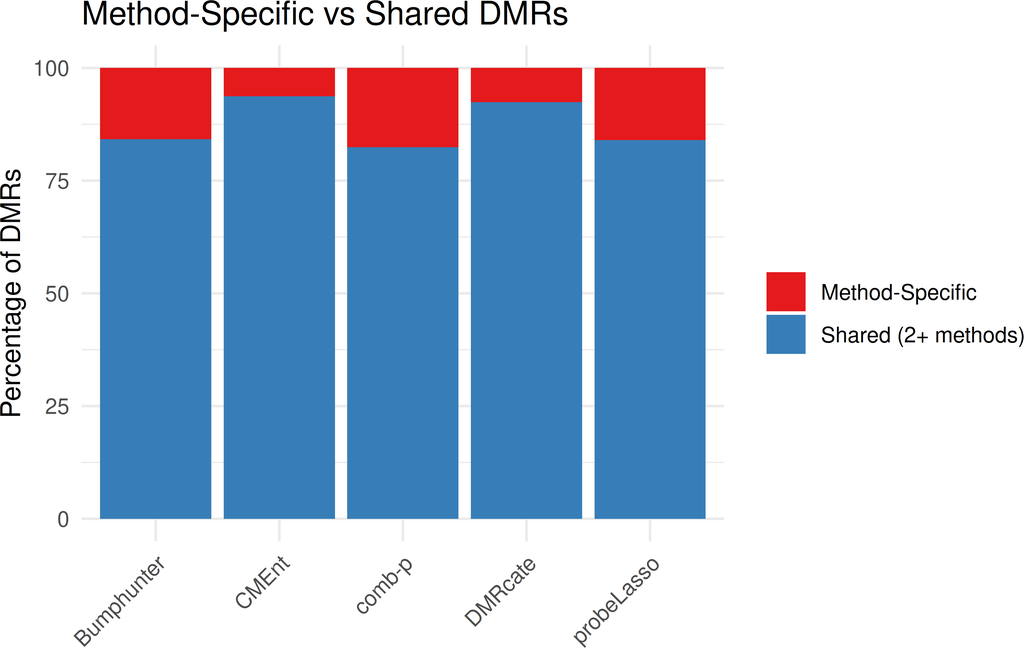

```r
specificity_plot_data <- specificity_df |>
    dplyr::select(Method, Pct_Specific, Pct_Shared_2plus) |>
    tidyr::pivot_longer(cols = -Method, names_to = "Type", values_to = "Percentage")

specificity_plot_data$Type <- ifelse(specificity_plot_data$Type == "Pct_Specific",
    "Method-Specific", "Shared (2+ methods)"
)

ggplot(specificity_plot_data, aes(x = Method, y = Percentage, fill = Type)) +
    geom_bar(stat = "identity", position = "stack") +
    theme_minimal() +
    theme(axis.text.x = element_text(angle = 45, hjust = 1)) +
    scale_fill_manual(values = c("Method-Specific" = "#E41A1C", "Shared (2+ methods)" = "#377EB8")) +
    labs(title = "Method-Specific vs Shared DMRs", x = "", y = "Percentage of DMRs", fill = "")
```

## 14 Example DMR Locus Visualization

```r
if (length(consensus_3plus) > 0) {
    top_consensus <- consensus_3plus[order(-mcols(consensus_3plus)$n_methods)][1]

    extended_region <- GRanges(
        seqnames = seqnames(top_consensus),
        ranges = IRanges(
            start = max(1, start(top_consensus) - 2000),
            end = end(top_consensus) + 2000
        )
    )

    cat(sprintf(
        "\nExample locus: %s:%d-%d (detected by %d methods)\n",
        as.character(seqnames(top_consensus)),
        start(top_consensus), end(top_consensus),
        mcols(top_consensus)$n_methods
    ))

    method_colors <- c(
        "CMEnt" = "#E41A1C", "comb-p" = "#377EB8",
        "probeLasso" = "#4DAF4A", "DMRcate" = "#984EA3",
        "Bumphunter" = "#FF7F00"
    )

    plot_data <- do.call(rbind, lapply(names(methods_list), function(method) {
        overlapping <- subsetByOverlaps(methods_list[[method]], extended_region)
        if (length(overlapping) > 0) {
            data.frame(
                Method = method,
                start = start(overlapping),
                end = end(overlapping),
                y = which(names(methods_list) == method)
            )
        } else {
            NULL
        }
    }))

    if (!is.null(plot_data) && nrow(plot_data) > 0) {
        p_locus <- ggplot(plot_data) +
            geom_rect(aes(
                xmin = start, xmax = end,
                ymin = y - 0.4, ymax = y + 0.4,
                fill = Method
            ), alpha = 0.7) +
            geom_vline(
                xintercept = c(start(top_consensus), end(top_consensus)),
                linetype = "dashed", color = "gray40"
            ) +
            scale_y_continuous(
                breaks = seq_along(methods_list),
                labels = names(methods_list)
            ) +
            scale_fill_manual(values = method_colors) +
            theme_minimal() +
            theme(
                legend.position = "none",
                panel.grid.minor = element_blank()
            ) +
            labs(
                title = sprintf(
                    "Example Consensus DMR: %s:%d-%d",
                    as.character(seqnames(top_consensus)),
                    start(top_consensus), end(top_consensus)
                ),
                subtitle = sprintf("Detected by %d methods", mcols(top_consensus)$n_methods),
                x = "Genomic Position", y = ""
            )

        print(p_locus)
    }
}
```

Example locus: chr1:853925-858362 (detected by 5 methods)

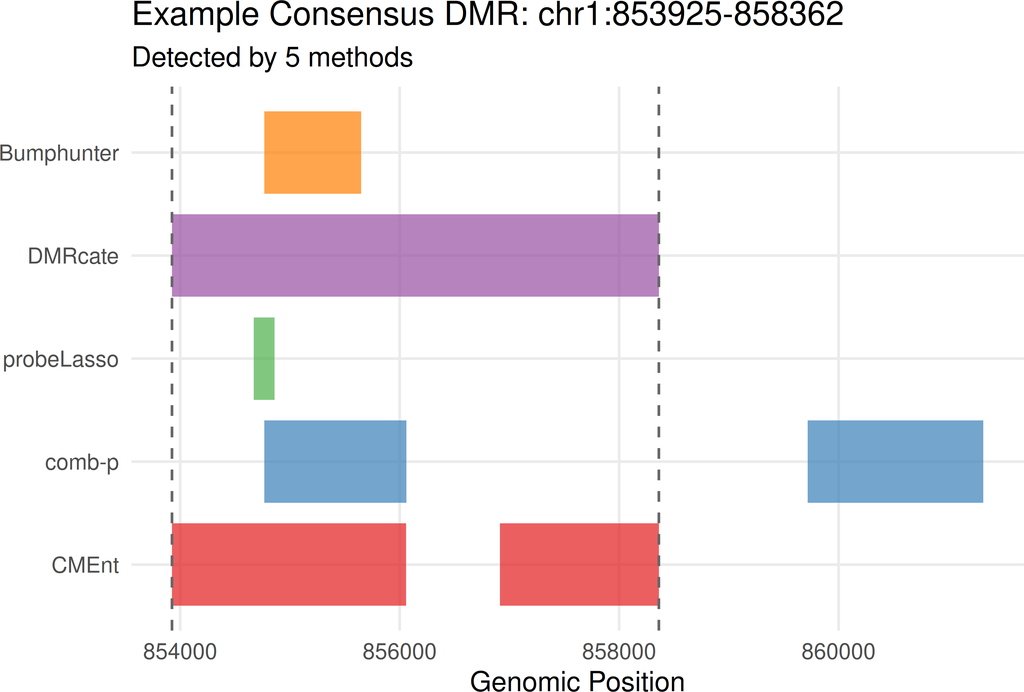

## 15 Method-Reported Region Significance

```r
significance_method_specs <- data.frame(
    Method = c("CMEnt", "comb-p", "probeLasso", "DMRcate", "Bumphunter"),
    Metric = c(
        "Not available",
        "Sidak-adjusted p-value",
        "Reported DMR p-value",
        "HMFDR",
        "FWER"
    ),
    Column = c(NA, "z_sidak_p", "dmrP", "HMFDR", "fwer"),
    stringsAsFactors = FALSE
)

method_dmrs <- list(
    CMEnt = dmrs_cment,
    `comb-p` = dmrs_combp,
    probeLasso = dmrs_probelasso,
    DMRcate = dmrs_dmrcate,
    Bumphunter = dmrs_bumphunter
)
method_colors_sig <- c(
    `comb-p` = "#377EB8",
    probeLasso = "#4DAF4A",
    DMRcate = "#984EA3",
    Bumphunter = "#FF7F00"
)

extract_region_significance <- function(dmrs, method, metric_label, value_col) {
    if (is.na(value_col) || length(dmrs) == 0 || !value_col %in% names(mcols(dmrs))) {
        return(NULL)
    }

    values <- suppressWarnings(as.numeric(mcols(dmrs)[[value_col]]))
    values <- values[is.finite(values)]
    if (length(values) == 0) {
        return(NULL)
    }

    data.frame(
        Method = method,
        Metric = metric_label,
        Reported_Error_Value = pmax(values, .Machine$double.xmin)
    )
}

region_significance_long <- do.call(rbind, Filter(Negate(is.null), lapply(seq_len(nrow(significance_method_specs)), function(i) {
    spec <- significance_method_specs[i, ]
    extract_region_significance(
        dmrs = method_dmrs[[spec$Method]],
        method = spec$Method,
        metric_label = spec$Metric,
        value_col = spec$Column
    )
})))

significance_method_specs$N_DMRs <- vapply(significance_method_specs$Method, function(method) {
    length(method_dmrs[[method]])
}, numeric(1))
significance_method_specs$Included_In_Plots <- vapply(seq_len(nrow(significance_method_specs)), function(i) {
    spec <- significance_method_specs[i, ]
    !is.na(spec$Column) && spec$Column %in% names(mcols(method_dmrs[[spec$Method]]))
}, logical(1))


region_significance_summary <- region_significance_long |>
    group_by(Method, Metric) |>
    summarise(
        N_DMRs = n(),
        Median_Reported_Value = signif(median(Reported_Error_Value), 3),
        Median_NegLog10 = round(median(-log10(Reported_Error_Value)), 2),
        Pct_Le_0_05 = round(100 * mean(Reported_Error_Value <= 0.05), 1),
        Pct_Le_0_01 = round(100 * mean(Reported_Error_Value <= 0.01), 1),
        .groups = "drop"
    )

knitr::kable(
    region_significance_summary,
    caption = "Summary of Method-Reported Region Significance Metrics"
)
```

Table 7: Summary of Method-Reported Region Significance Metrics

| Method | Metric | N_DMRs | Median_Reported_Value | Median_NegLog10 | Pct_Le_0_05 | Pct_Le_0_01 |
| --- | --- | --- | --- | --- | --- | --- |
| Bumphunter | FWER | 11372 | 5.50e-01 | 0.26 | 13.2 | 4.7 |
| DMRcate | HMFDR | 11239 | 1.50e-06 | 5.84 | 100.0 | 100.0 |
| comb-p | Sidak-adjusted p-value | 17981 | 4.48e-05 | 4.35 | 100.0 | 86.3 |
| probeLasso | Reported DMR p-value | 10541 | 0.00e+00 | 7.67 | 100.0 | 99.1 |

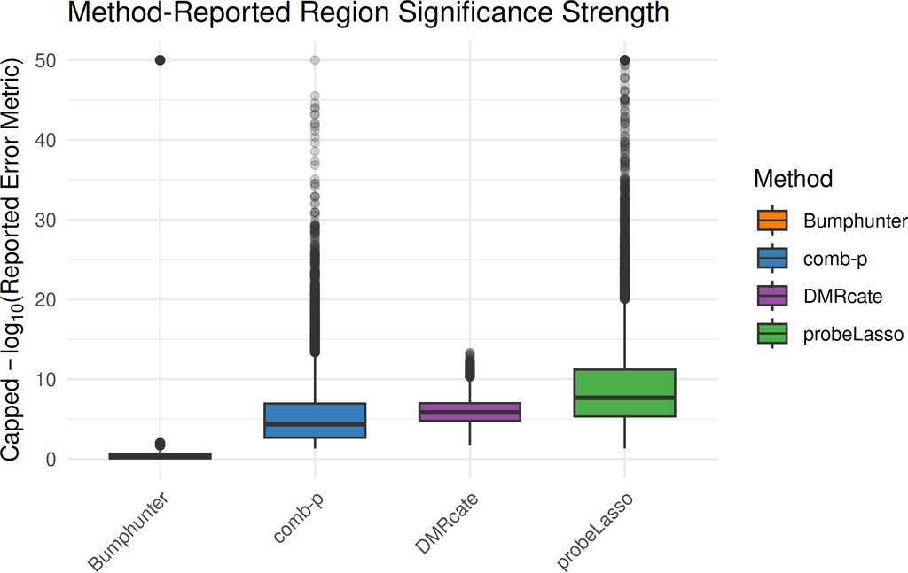

```r
if (exists("region_significance_long") && nrow(region_significance_long) > 0) {
    region_significance_long$NegLog10_Reported_Error <- pmin(-log10(region_significance_long$Reported_Error_Value), 50)

    ggplot(region_significance_long, aes(x = Method, y = NegLog10_Reported_Error, fill = Method)) +
        geom_boxplot(outlier.alpha = 0.2, width = 0.65) +
        scale_fill_manual(values = method_colors_sig) +
        theme_minimal() +
        theme(axis.text.x = element_text(angle = 45, hjust = 1)) +
        labs(
            title = "Method-Reported Region Significance Strength",
            x = "", y = expression(paste("Capped ", -log[10], "(Reported Error Metric)")), fill = "Method"
        )
}
```

## 16 CMEnt Score vs Overlapping Region Significance

```r
match_cment_to_method_significance <- function(cment_dmrs, method_dmrs, method, metric_label, value_col) {
    if (length(cment_dmrs) == 0 || length(method_dmrs) == 0 || !value_col %in% names(mcols(method_dmrs))) {
        return(NULL)
    }

    method_values <- suppressWarnings(as.numeric(mcols(method_dmrs)[[value_col]]))
    keep_subjects <- is.finite(method_values)
    if (!any(keep_subjects)) {
        return(NULL)
    }
    method_dmrs <- method_dmrs[keep_subjects]
    method_values <- pmax(method_values[keep_subjects], .Machine$double.xmin)

    hits <- findOverlaps(cment_dmrs, method_dmrs, ignore.strand = TRUE)
    if (length(hits) == 0) {
        return(NULL)
    }

    query_idx <- queryHits(hits)
    subject_idx <- subjectHits(hits)
    intersection_start <- pmax(start(cment_dmrs)[query_idx], start(method_dmrs)[subject_idx])
    intersection_end <- pmin(end(cment_dmrs)[query_idx], end(method_dmrs)[subject_idx])
    intersection_width <- pmax(0L, intersection_end - intersection_start + 1L)
    union_width <- width(cment_dmrs)[query_idx] + width(method_dmrs)[subject_idx] - intersection_width
    jaccard <- intersection_width / union_width

    overlap_tbl <- data.frame(
        Query_Index = query_idx,
        Subject_Index = subject_idx,
        Jaccard = jaccard,
        Reported_Error_Value = method_values[subject_idx]
    ) |>
        arrange(Query_Index, desc(Jaccard), Reported_Error_Value, Subject_Index) |>
        distinct(Query_Index, .keep_all = TRUE)

    data.frame(
        Method = method,
        Metric = metric_label,
        Query_Index = overlap_tbl$Query_Index,
        CMEnt_Score = as.numeric(mcols(cment_dmrs)$score[overlap_tbl$Query_Index]),
        Reported_Error_Value = overlap_tbl$Reported_Error_Value,
        NegLog10_Reported_Error = -log10(overlap_tbl$Reported_Error_Value),
        Best_Jaccard = overlap_tbl$Jaccard
    )
}

cment_significance_correlation_long <- do.call(rbind, Filter(Negate(is.null), lapply(seq_len(nrow(significance_method_specs)), function(i) {
    spec <- significance_method_specs[i, ]
    if (spec$Method == "CMEnt" || is.na(spec$Column)) {
        return(NULL)
    }
    match_cment_to_method_significance(
        cment_dmrs = dmrs_cment,
        method_dmrs = method_dmrs[[spec$Method]],
        method = spec$Method,
        metric_label = spec$Metric,
        value_col = spec$Column
    )
})))

cment_significance_correlation_summary <- cment_significance_correlation_long |>
    group_by(Method, Metric) |>
    summarise(
        N_Overlapping_CMEnt_DMRs = n(),
        Spearman_Rho = round(cor(CMEnt_Score, NegLog10_Reported_Error, method = "spearman"), 3),
        Pearson_R = round(cor(CMEnt_Score, NegLog10_Reported_Error, method = "pearson"), 3),
        Median_Best_Jaccard = round(median(Best_Jaccard), 3),
        Median_Reported_Value = signif(median(Reported_Error_Value), 3),
        .groups = "drop"
    )

knitr::kable(
    cment_significance_correlation_summary,
    caption = "Correlation of CMEnt Score with Best-Matched Overlapping Region Significance"
)
```

Table 8: Correlation of CMEnt Score with Best-Matched Overlapping Region Significance

| Method | Metric | N_Overlapping_CMEnt_DMRs | Spearman_Rho | Pearson_R | Median_Best_Jaccard | Median_Reported_Value |
| --- | --- | --- | --- | --- | --- | --- |
| Bumphunter | FWER | 6116 | 0.315 | 0.205 | 0.243 | 4.2e-01 |
| DMRcate | HMFDR | 7043 | 0.597 | 0.581 | 0.693 | 9.0e-07 |
| comb-p | Sidak-adjusted p-value | 10138 | 0.385 | 0.368 | 0.527 | 4.4e-06 |
| probeLasso | Reported DMR p-value | 5800 | 0.335 | 0.274 | 0.182 | 0.0e+00 |

One best-overlap match per CMEnt DMR and method, selected by maximum Jaccard

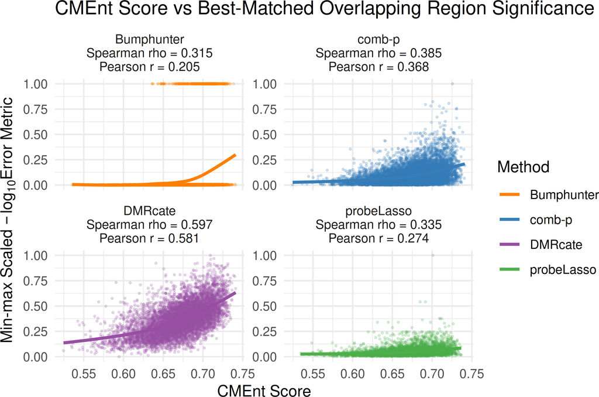

```r
if (exists("cment_significance_correlation_long") && nrow(cment_significance_correlation_long) > 0) {
    cment_significance_correlation_long$NegLog10_Reported_Error_Scaled <- group_by(cment_significance_correlation_long, Method) |>
        mutate(NegLog10_Reported_Error_Scaled = scales::rescale(NegLog10_Reported_Error, to = c(0, 1))) |>
        pull(NegLog10_Reported_Error_Scaled)
    cment_significance_correlation_long$Correlation_Label <- sprintf(
        "Spearman rho = %.3f\nPearson r = %.3f",
        cment_significance_correlation_summary$Spearman_Rho[match(cment_significance_correlation_long$Method, cment_significance_correlation_summary$Method)],
        cment_significance_correlation_summary$Pearson_R[match(cment_significance_correlation_long$Method, cment_significance_correlation_summary$Method)]
    )
    cment_significance_correlation_long$MethodWithLabel <- paste0(cment_significance_correlation_long$Method, "\n", cment_significance_correlation_long$Correlation_Label)
    ggplot(
        cment_significance_correlation_long,
        aes(x = CMEnt_Score, y = NegLog10_Reported_Error_Scaled, color = Method)
    ) +
        geom_point(alpha = 0.18, size = 0.4) +
        geom_smooth(se = FALSE, linewidth = 1) +
        facet_wrap(~MethodWithLabel, scales = "free_y") +
        scale_color_manual(values = method_colors_sig) +
        theme_minimal() +
        labs(
            title = "CMEnt Score vs Best-Matched Overlapping Region Significance",
            x = "CMEnt Score",
            y = expression(paste("Min-max Scaled ", -log[10], "Error Metric")),
            color = "Method"
        )
}
```

## 17 Summary Statistics

```r
summary_table <- results_comparison |>
    left_join(effect_size_df, by = "Method") |>
    left_join(capture_df, by = "Method") |>
    left_join(specificity_df |> dplyr::select(Method, Pct_Specific, Pct_Shared_2plus, Pct_Shared_3plus), by = "Method")

knitr::kable(summary_table, digits = 2, caption = "Comprehensive Method Comparison Summary")
```

Table 9: Comprehensive Method Comparison Summary

| Method | Number.of.DMRs | Mean.DMR.Width | Median.DMR.Width | Total.Coverage.bp | Min.Width | Max.Width | Mean_Delta_Beta | Capture_Rate_Pct | Pct_Specific | Pct_Shared_2plus | Pct_Shared_3plus |
| --- | --- | --- | --- | --- | --- | --- | --- | --- | --- | --- | --- |
| CMEnt | 12562 | 961.7 | 754 | 12080749 | 7 | 10546 | 0.10 | 80.86 | 6.3 | 93.7 | 74.5 |
| comb-p | 17981 | 930.2 | 816 | 16725476 | 9 | 10159 | 0.09 | 91.49 | 17.6 | 82.4 | 59.4 |
| probeLasso | 10541 | 2426.2 | 2033 | 25574771 | 52 | 26740 | 0.09 | 63.96 | 16.0 | 84.0 | 65.9 |
| DMRcate | 11239 | 1103.0 | 896 | 12396187 | 10 | 13647 | 0.11 | 79.00 | 7.6 | 92.4 | 75.6 |
| Bumphunter | 11372 | 498.4 | 260 | 5667409 | 3 | 11785 | 0.18 | 66.94 | 15.8 | 84.2 | 75.6 |

```r
cat("\n## Key Findings\n\n")
```

## 18 Key Findings

```r
if (nrow(results_comparison) > 0) {
    max_dmrs <- results_comparison[which.max(results_comparison$Number_of_DMRs), ]
    min_dmrs <- results_comparison[which.min(results_comparison$Number_of_DMRs), ]

    cat(sprintf(
        "- **%s** detected the most DMRs (%d regions)\n",
        max_dmrs$Method, max_dmrs$Number_of_DMRs
    ))
    cat(sprintf(
        "- **%s** was most selective (%d regions)\n",
        min_dmrs$Method, min_dmrs$Number_of_DMRs
    ))

    if (exists("capture_df") && nrow(capture_df) > 0) {
        best_capture <- capture_df[which.max(capture_df$Capture_Rate_Pct), ]
        cat(sprintf(
            "- **%s** captured %.1f%% of high-confidence (3+ methods) DMRs\n",
            best_capture$Method, best_capture$Capture_Rate_Pct
        ))
    }

    if (exists("effect_size_df") && nrow(effect_size_df) > 0) {
        best_effect <- effect_size_df[which.max(effect_size_df$Mean_Delta_Beta), ]
        cat(sprintf(
            "- **%s** had the highest mean effect size (delta beta = %.4f)\n",
            best_effect$Method, best_effect$Mean_Delta_Beta
        ))
    }

    if (exists("specificity_df") && "CMEnt" %in% specificity_df$Method) {
        cment_row <- specificity_df[specificity_df$Method == "CMEnt", ]
        cat(sprintf(
            "- **CMEnt**: %.1f%% method-specific, %.1f%% shared with at least 2 methods, %.1f%% shared with at least 3 methods\n",
            cment_row$Pct_Specific, cment_row$Pct_Shared_2plus, cment_row$Pct_Shared_3plus
        ))
    }
}
```

- **comb-p** captured 91.5% of high-confidence (3+ methods) DMRs
- **Bumphunter** had the highest mean effect size (delta beta = 0.1823)
- **CMEnt**: 6.3% method-specific, 93.7% shared with at least 2 methods, 74.5% shared with at least 3 methods

[session information not shown]

R version 4.6.0 (2026-04-24) Platform: x86_64-pc-linux-gnu Running under: Ubuntu 24.04.4 LTS

Matrix products: default BLAS: /usr/lib/x86_64-linux-gnu/openblas-pthread/libblas.so.3 LAPACK: /usr/lib/x86_64-linux-gnu/openblas-pthread/libopenblasp-r0.3.26.so; LAPACK version 3.12.0

locale: [1] LC_CTYPE=C.UTF-8 LC_NUMERIC=C LC_TIME=C.UTF-8  
[4] LC_COLLATE=C.UTF-8 LC_MONETARY=C.UTF-8 LC_MESSAGES=C.UTF-8  
[7] LC_PAPER=C.UTF-8 LC_NAME=C LC_ADDRESS=C  
[10] LC_TELEPHONE=C LC_MEASUREMENT=C.UTF-8 LC_IDENTIFICATION=C

time zone: Europe/Brussels tzcode source: system (glibc)

attached base packages: [1] parallel stats4 stats graphics grDevices datasets utils  
[8] methods base

other attached packages: [1] UpSetR_1.4.0  
[2] IlluminaHumanMethylation450kanno.ilmn12.hg19_0.6.1 [3] TxDb.Hsapiens.UCSC.hg19.knownGene_3.22.1  
[4] GenomicFeatures_1.64.0  
[5] AnnotationDbi_1.74.0  
[6] reshape2_1.4.5  
[7] DMRsegaldata_1.0.0  
[8] ExperimentHub_3.2.0  
[9] AnnotationHub_4.2.0  
[10] BiocFileCache_3.2.0  
[11] dbplyr_2.5.2  
[12] dplyr_1.2.1  
[13] ggplot2_4.0.3  
[14] data.table_1.18.4  
[15] minfi_1.58.0  
[16] bumphunter_1.54.0  
[17] locfit_1.5-9.12  
[18] iterators_1.0.14  
[19] foreach_1.5.2  
[20] Biostrings_2.80.0  
[21] XVector_0.52.0  
[22] SummarizedExperiment_1.42.0  
[23] Biobase_2.72.0  
[24] MatrixGenerics_1.24.0  
[25] matrixStats_1.5.0  
[26] GenomicRanges_1.64.0  
[27] Seqinfo_1.2.0  
[28] IRanges_2.46.0  
[29] S4Vectors_0.50.1  
[30] BiocGenerics_0.58.1  
[31] generics_0.1.4  
[32] CMEnt_0.99.0  
[33] testthat_3.3.2  
[34] BiocStyle_2.40.0

loaded via a namespace (and not attached): [1] fs_2.1.0 bitops_1.0-9  
[3] DirichletMultinomial_1.54.0 devtools_2.5.2  
[5] TFBSTools_1.50.0 httr_1.4.8  
[7] RColorBrewer_1.1-3 doParallel_1.0.17  
[9] backports_1.5.1 doRNG_1.8.6.3  
[11] tools_4.6.0 R6_2.6.1  
[13] DT_0.34.0 HDF5Array_1.40.0  
[15] mgcv_1.9-4 lazyeval_0.2.3  
[17] rhdf5filters_1.24.0 GetoptLong_1.1.1  
[19] permute_0.9-10 withr_3.0.2  
[21] gridExtra_2.3 base64_2.0.2  
[23] preprocessCore_1.74.0 VennDiagram_1.8.2  
[25] cli_3.6.6 formatR_1.14  
[27] labeling_0.4.3 sass_0.4.10  
[29] S7_0.2.2 genefilter_1.94.0  
[31] readr_2.2.0 askpass_1.2.1  
[33] proxy_0.4-29 Rsamtools_2.28.0  
[35] illuminaio_0.54.0 siggenes_1.86.0  
[37] R.utils_2.13.0 rentrez_1.2.4  
[39] dichromat_2.0-0.1 showtext_0.9-8  
[41] scrime_1.3.7 parallelly_1.47.0  
[43] sessioninfo_1.2.3 BSgenome_1.80.0  
[45] limma_3.68.2 strex_2.0.1  
[47] rstudioapi_0.18.0 sysfonts_0.8.9  
[49] RSQLite_3.52.0 FNN_1.1.4.1  
[51] shape_1.4.6.1 BiocIO_1.22.0  
[53] gtools_3.9.5 bedr_1.1.5  
[55] inline_0.3.21 Matrix_1.7-5  
[57] futile.logger_1.4.9 abind_1.4-8  
[59] R.methodsS3_1.8.2 lifecycle_1.0.5  
[61] yaml_2.3.12 rhdf5_2.56.0  
[63] SparseArray_1.12.2 grid_4.6.0  
[65] blob_1.3.0 promises_1.5.0  
[67] crayon_1.5.3 pwalign_1.8.0  
[69] lattice_0.22-9 beachmat_2.28.0  
[71] annotate_1.90.0 cigarillo_1.2.0  
[73] KEGGREST_1.52.0 magick_2.9.1  
[75] beanplot_1.3.1 pillar_1.11.1  
[77] knitr_1.51 ComplexHeatmap_2.28.0  
[79] rjson_0.2.23 future.apply_1.20.2  
[81] codetools_0.2-20 glue_1.8.1  
[83] vctrs_0.7.3 png_0.1-9  
[85] gtable_0.3.6 cachem_1.1.0  
[87] xfun_0.57 S4Arrays_1.12.0  
[89] mime_0.13 survival_3.8-6  
[91] DelayedDataFrame_1.28.0 tinytex_0.59  
[93] showtextdb_3.0 statmod_1.5.2  
[95] ellipsis_0.3.3 nlme_3.1-168  
[97] usethis_3.2.1 bit64_4.8.2  
[99] bsseq_1.48.0 filelock_1.0.3  
[101] GenomeInfoDb_1.48.0 rprojroot_2.1.1  
[103] nor1mix_1.3-3 bslib_0.11.0  
[105] otel_0.2.0 colorspace_2.1-2  
[107] seqLogo_1.78.0 DBI_1.3.0  
[109] tidyselect_1.2.1 processx_3.9.0  
[111] bit_4.6.0 compiler_4.6.0  
[113] curl_7.1.0 httr2_1.2.2  
[115] h5mread_1.4.0 xml2_1.5.2  
[117] desc_1.4.3 DelayedArray_0.38.1  
[119] plotly_4.12.0 bookdown_0.46  
[121] rtracklayer_1.72.0 checkmate_2.3.4  
[123] scales_1.4.0 caTools_1.18.3  
[125] quadprog_1.5-8 callr_3.7.6  
[127] rappdirs_0.3.4 stringr_1.6.0  
[129] digest_0.6.39 rmarkdown_2.31  
[131] GEOquery_2.80.0 bspm_0.5.8  
[133] htmltools_0.5.9 pkgconfig_2.0.3  
[135] sparseMatrixStats_1.24.0 fastmap_1.2.0  
[137] rlang_1.2.0 GlobalOptions_0.1.4  
[139] htmlwidgets_1.6.4 UCSC.utils_1.8.0  
[141] shiny_1.13.0 DelayedMatrixStats_1.34.0  
[143] farver_2.1.2 jquerylib_0.1.4  
[145] jsonlite_2.0.0 mclust_6.1.2  
[147] BiocParallel_1.46.0 R.oo_1.27.1  
[149] RCurl_1.98-1.18 magrittr_2.0.5  
[151] Rhdf5lib_2.0.0 Rcpp_1.1.1-1.1  
[153] shinycssloaders_1.1.0 stringi_1.8.7  
[155] MASS_7.3-65 brio_1.1.5  
[157] plyr_1.8.9 pkgbuild_1.4.8  
[159] ggseqlogo_0.2.2 listenv_0.10.1  
[161] splines_4.6.0 multtest_2.68.0  
[163] hms_1.1.4 circlize_0.4.18  
[165] ps_1.9.3 igraph_2.3.1  
[167] rngtools_1.5.2 pkgload_1.5.2  
[169] futile.options_1.0.1 TFMPvalue_1.0.0  
[171] BiocVersion_3.23.1 XML_3.99-0.23  
[173] evaluate_1.0.5 lambda.r_1.2.4  
[175] BiocManager_1.30.27 tzdb_0.5.0  
[177] httpuv_1.6.17 openssl_2.4.1  
[179] tidyr_1.3.2 purrr_1.2.2  
[181] reshape_0.8.10 future_1.70.0  
[183] clue_0.3-68 gridBase_0.4-7  
[185] xtable_1.8-8 restfulr_0.0.16  
[187] e1071_1.7-17 later_1.4.8  
[189] viridisLite_0.4.3 class_7.3-23  
[191] tibble_3.3.1 memoise_2.0.1  
[193] GenomicAlignments_1.48.0 cluster_2.1.8.2  
[195] globals_0.19.1